# R Notebook

Week 11 Day 1

Logistic Regression

Binary dependent variable (0 | 1)

- spam emails or not
- married or not
- clicked or not
- organic avocados or conventional
- registered user or not
- accepted user or not

| tu_score | employed | age | accepted |
| --- | --- | --- | --- |
| 433 | TRUE | 28 | TRUE |
| 93 | TRUE | 52 | FALSE |
| 368 | FALSE | 63 | FALSE |
| 665 | TRUE | 42 | TRUE |
| 687 | TRUE | 38 | TRUE |
| 594 | TRUE | 27 | FALSE |
| 83 | FALSE | 24 | FALSE |
| 172 | TRUE | 19 | FALSE |
| 27 | FALSE | 45 | FALSE |
| 232 | FALSE | 34 | FALSE |

[output cut: 990 more lines]

```r
library(GGally)

ggpairs(mortage_data)
```

[output not shown]

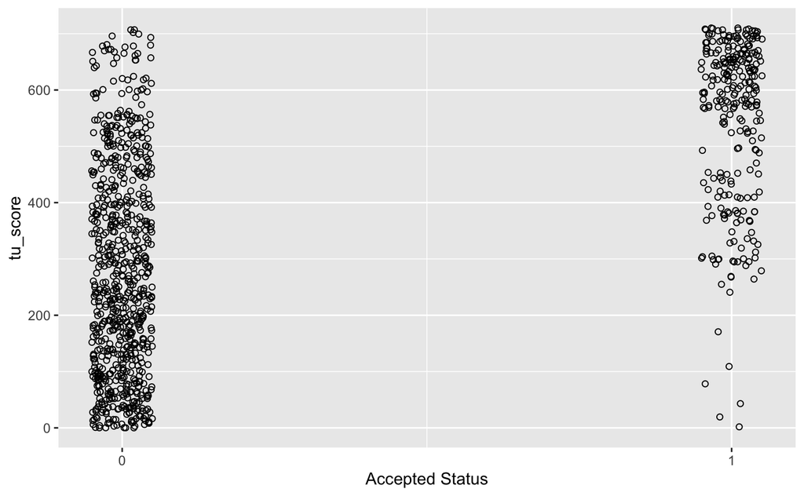

```r
# Let's reduce the symbol size and 'jitter' the y-values so we can see more of the data without overlap of symbols
# geom_jitter() adds adds a small amount of random variation (vertically and/ore horizontally depending on the arguments) to the location of each point

score_plot <- ggplot(mortgage_data) +
  geom_jitter(aes(y = tu_score, x = as.integer(accepted)), shape = 1,
              position = position_jitter(width = 0.05)) +
  xlab("Accepted Status") + scale_x_continuous(breaks=seq(0, 1,1))

score_plot
```

# Logistic function

Logistic regression is estimating the LOG ODDS of an event, rather than the probability

Calculating the odds (vs probability), is: successes of event / potential event outcomes = odds (e.g. 4 wins / 6 failures, out of 10 games = 4:6 odds) probability is: (total poss) / 1-(total poss / all outcomes / ) = 4 wins / 1-(6+4) = 4/10 = 40%

```r
logit <- function(x){
  return(log(x/(1-x)))
}

logit_data <- tibble(p = seq(0.001, 0.999, 0.001)) %>%
  mutate(logit_p = logit(p))

head(logit_data)
```

| p | logit_p |
| --- | --- |
| 0.001 | -6.906755 |
| 0.002 | -6.212606 |
| 0.003 | -5.806138 |
| 0.004 | -5.517453 |
| 0.005 | -5.293305 |
| 0.006 | -5.109978 |

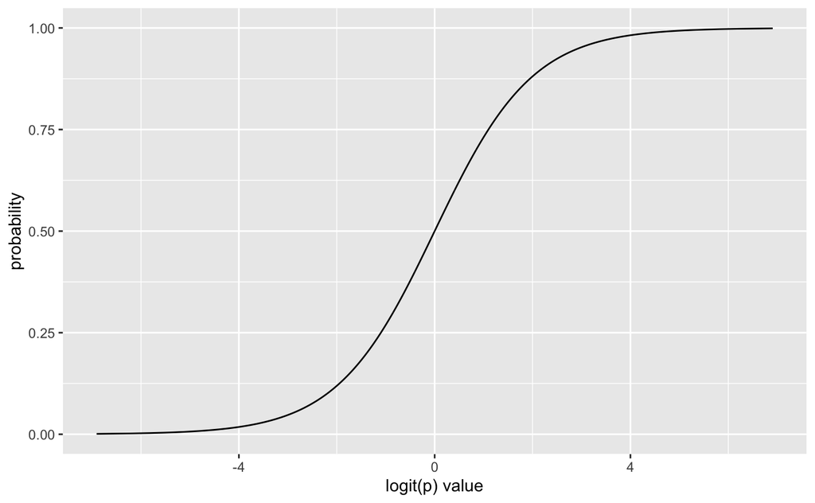

```r
ggplot(logit_data, aes(y = p, x = logit_p)) +
  geom_line() +
  ylab("probability") + xlab("logit(p) value")
```

** BREAK **

Model building time

Build a model that predicts the probability of a loan being accepted or not, given a tu_score

1. build the logistic model

```r
mortgage_data_log_model <- glm(accepted ~ tu_score, data = mortgage_data,
                               family = binomial(link = 'logit'))

mortgage_data_log_model
```

```
Call:  glm(formula = accepted ~ tu_score, family = binomial(link = "logit"),
    data = mortgage_data)

Coefficients:
(Intercept)     tu_score
  -4.575035     0.008475

Degrees of Freedom: 999 Total (i.e. Null);  998 Residual
Null Deviance:      1170
Residual Deviance: 792.1    AIC: 796.1
```

B0 = intercept

2. add these predictions into your dataset

```r
library(modelr)

predict_log <- tibble(tu_score = seq(0, 710, 1)) %>%
  add_predictions(mortgage_data_log_model, type = 'response')
```

3. Check model fits the data

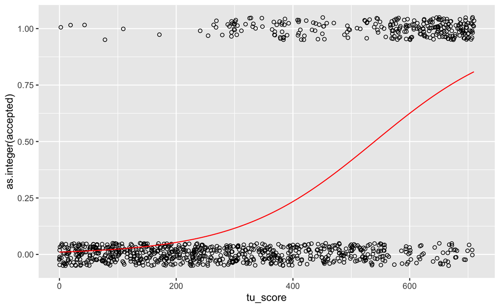

```r
ggplot(mortgage_data) +
  geom_jitter(aes(x = tu_score, y = as.integer(accepted)), shape = 1, position = position_jitter(h = 0.05)) +
  geom_line(data = predict_log, aes(x = tu_score, y = pred), col = "red")
```

Task Use and amend the code above to predict the probability of getting a mortgage application accepted with a tu_score of 594.

| tu_score | pred |
| --- | --- |
| 594 | 0.6127971 |

This is only the probability, NOT the odds.

4. Interpreting the B1 for a continuous predictor (tu_score)

If the independent variables increases by 1 unit, then the estimate of the log odds of the success changes (increases or decreases) by B1 units.

Calculate the odds of having an accepted application at tu_score = 594

| tu_score | pred | odds |
| --- | --- | --- |
| 594 | 0.6127971 | 1.582625 |

How do these odds change if we increase the tu_score by 50 points?

| estimate |
| --- |
| 0.00847495 |

| estimate |
| --- |
| 1.527676 |

Calculate the new odds of getting a loan accepted or not, based on a 50 point increase in tu_score

| odds |
| --- |
| 1.582625 |

```r
new_odds <- odds_factor * odds_at_594
new_odds
```

| estimate |
| --- |
| 2.417739 |

The old odds were 1.58, the new odds are 2.41 - so the odds have improved. To check this, we can run the calculation in the same code as before.

| tu_score | pred | odds |
| --- | --- | --- |
| 644 | 0.7074089 | 2.417739 |

Task How do the odds change if the tu_score decreases by 50?

| tu_score | pred | odds |
| --- | --- | --- |
| 544 | 0.5088335 | 1.035969 |

Decreases to 1.03

** LUNCH BREAK**

Make a new model with multiple predictors

```r
mortgage_multi_log_model <- glm(accepted ~ tu_score + employed + age,
                                data = mortgage_data,
                               family = binomial(link = 'logit'))

mortgage_multi_log_model
```

```
Call:  glm(formula = accepted ~ tu_score + employed + age, family = binomial(link = "logit"),
    data = mortgage_data)

Coefficients:
 (Intercept)      tu_score  employedTRUE           age
    -4.62854       0.00673       1.48034      -0.00126

Degrees of Freedom: 999 Total (i.e. Null);  996 Residual
Null Deviance:      1170
Residual Deviance: 740  AIC: 748
```

| term | estimate | std.error | statistic | p.value |
| --- | --- | --- | --- | --- |
| (Intercept) | -4.628539329 | 0.4303343969 | -10.7556806 | 5.572114e-27 |
| tu_score | 0.006730118 | 0.0005692479 | 11.8228250 | 2.975086e-32 |
| employedTRUE | 1.480341044 | 0.2114793584 | 6.9999316 | 2.560875e-12 |
| age | -0.001260001 | 0.0070633577 | -0.1783856 | 8.584202e-01 |

age is NOT stat sig = 0.8584202

Final model will be: accepted ~ tu_score + employed

| estimate |
| --- |
| 4.394444 |

On average, a customer’s odds of being accepted for a mortgage are 4.39 times higher if they are employed.

# Lesson 2

# Evaluating the Performance of a model

So now that we’ve built a model, we’re going to work with the dataset to see what it’s saying about our data.

```r
mortgage_3pred_model <- glm(accepted ~ tu_score + employed + age,
                            data = mortgage_data,
                            family = binomial(link = 'logit'))

mortgage_data_with_3pred <- mortgage_data %>%
  add_predictions(mortgage_3pred_model, type = "response")
head(mortgage_data_with_3pred)
```

| tu_score | employed | age | accepted | pred |
| --- | --- | --- | --- | --- |
| 433 | TRUE | 28 | TRUE | 0.43306982 |
| 93 | TRUE | 52 | FALSE | 0.06992660 |
| 368 | FALSE | 63 | FALSE | 0.09698035 |
| 665 | TRUE | 42 | TRUE | 0.78149676 |
| 687 | TRUE | 38 | TRUE | 0.80651348 |
| 594 | TRUE | 27 | FALSE | 0.69327429 |

**Threshold probability** - Cut off for whether a value gets classed as true or false, that depends on a certain prob level

Set the threshold to 0.6

```r
threshold <- 0.6

mortgage_data_with_3pred <- mortgage_data_with_3pred %>%
  mutate(pred_thresh_0.6 = pred > threshold)

mortgage_data_with_3pred
```

| tu_score | employed | age | accepted | pred | pred_thresh_0.6 |
| --- | --- | --- | --- | --- | --- |
| 433 | TRUE | 28 | TRUE | 0.433069819 | FALSE |
| 93 | TRUE | 52 | FALSE | 0.069926601 | FALSE |
| 368 | FALSE | 63 | FALSE | 0.096980347 | FALSE |
| 665 | TRUE | 42 | TRUE | 0.781496763 | TRUE |
| 687 | TRUE | 38 | TRUE | 0.806513482 | TRUE |
| 594 | TRUE | 27 | FALSE | 0.693274287 | TRUE |
| 83 | FALSE | 24 | FALSE | 0.016299620 | FALSE |
| 172 | TRUE | 19 | FALSE | 0.117682879 | FALSE |
| 27 | FALSE | 45 | FALSE | 0.010948692 | FALSE |
| 232 | FALSE | 34 | FALSE | 0.042696972 | FALSE |

[output cut: 990 more lines]

Count how many times our classifier/model is correct

```r
conf_table
```

```
 accepted FALSE TRUE
    FALSE   679   49
     TRUE    93  179
```

Task

| tu_score | employed | age | accepted | pred | pred_thresh_0.6 |
| --- | --- | --- | --- | --- | --- |
| 433 | TRUE | 28 | TRUE | 0.433069819 | FALSE |
| 93 | TRUE | 52 | FALSE | 0.069926601 | FALSE |
| 368 | FALSE | 63 | FALSE | 0.096980347 | FALSE |
| 665 | TRUE | 42 | TRUE | 0.781496763 | TRUE |
| 687 | TRUE | 38 | TRUE | 0.806513482 | TRUE |
| 594 | TRUE | 27 | FALSE | 0.693274287 | TRUE |
| 83 | FALSE | 24 | FALSE | 0.016299620 | FALSE |
| 172 | TRUE | 19 | FALSE | 0.117682879 | FALSE |
| 27 | FALSE | 45 | FALSE | 0.010948692 | FALSE |
| 232 | FALSE | 34 | FALSE | 0.042696972 | FALSE |

[output cut: 990 more lines]

# Accuracy score

What is the accuracy of a classifier?

(total positives + total negatives) / total outcomes

679+179 = 858

858 / 1000

it is 85% (roughly)

Task The weakness of accuracy appears mainly when it is applied to unbalanced datasets. Imagine getting a mortgage is really easy, and we have a sample dataset with 900 ‘accepted’ and 100 ‘declined’ applications. This dataset is unbalanced: the ratio of outcomes isn’t approximately 1:1. Also imagine we apply a classifier with a threshold probability of zero, an ‘always accept’ classifier. What will the accuracy of this classifier be? What is the problem?

There is no classifier / predictive power - the model is only being lucky in predicting the outcome.

# Rates

Performance measures of the classifier/model.

> True positive rate = NTP / NTP + NFN TPR: the number of positive cases that are correctly identified/classified. This is sometimes called the **sensitivity**.

> True negative rate = NTN / NTN + NFP TNR: the number of negative cases that are correctly idenfied/classified. Sometimes called the **specificity**.

> False positive rate = NFP / NFP + NTN FPR: False alarm rate - negative cases that are incorrectly identified as positive. Also known as **type I error**

> False negative rate = NFN / NFN + NTP FNR: Incorrectly identifies a case as negative when it’s positive :( :( :( **type II error**

values from confusion matrix

```r
TPR
```

```
[1] 0.6580882
```

```r
TNR
```

```
[1] 0.9326923
```

```r
FPR
```

```
[1] 0.06730769
```

```r
FNR
```

```
[1] 0.3419118
```

** BREAK **

# ROC Curves, AUC, Gini coefficients, and cross validation

```r
summary(mortgage_3pred_model)
```

```
Call:
glm(formula = accepted ~ tu_score + employed + age, family = binomial(link = "logit"),
    data = mortgage_data)

Deviance Residuals:
    Min       1Q   Median       3Q      Max
-1.8827  -0.5069  -0.2852   0.6390   2.9650

Coefficients:
               Estimate Std. Error z value Pr(>|z|)
(Intercept)  -4.6285393  0.4303344 -10.756  < 2e-16 ***
tu_score      0.0067301  0.0005692  11.823  < 2e-16 ***
employedTRUE  1.4803410  0.2114794   7.000 2.56e-12 ***
age          -0.0012600  0.0070634  -0.178    0.858
---
Signif. codes:  0 ‘***’ 0.001 ‘**’ 0.01 ‘*’ 0.05 ‘.’ 0.1 ‘ ’ 1

(Dispersion parameter for binomial family taken to be 1)

    Null deviance: 1170.48  on 999  degrees of freedom
Residual deviance:  739.95  on 996  degrees of freedom
AIC: 747.95

Number of Fisher Scoring iterations: 5
```

# ROC curves

ROC is receiver operator characteristic

```r
library(pROC)

roc_obj_3pred <- mortgage_data_with_3pred %>%
  roc(response = accepted, predictor = pred)
```

```r
ggroc(data = roc_obj_3pred, legacy.axes = TRUE) +
  coord_fixed() +
  ylab("sensitivity (TPR)") +
  xlab("1-specificity (FPR)")
```

[output not shown]

```r
classifier_data <- tibble(
  threshold = roc_obj_3pred$thresholds,
  sensitivity = roc_obj_3pred$sensitivities,
  specificity = roc_obj_3pred$specificities
)

head(classifier_data)
```

[output not shown]

Task

OK, let’s fit another classifier and add its curve to the ROC plot from earlier!

- Fit a single predictor logistic regression model to the mortgage_data. We recommend tu_score as the predictor. Save the model as mortgage_1pred_model
- Add the predicted probabilities from this model to mortgage_data, and save the resulting data as mortgage_data_with_1pred
- Use this data to generate an an object from roc(), save the object as roc_obj_1pred
- Pass your old roc_obj_3pred and new roc_obj_1pred into ggroc() [Hint check the ggroc() docs to see how to pass in multiple roc objects].
- Given these ROC curves, which classifier is better?
- If you have time, try another single predictor, i.e. age or employed

```r
mortgage_1pred_model <- glm(accepted ~ tu_score,
                                data = mortgage_data,
                               family = binomial(link = 'logit'))
mortgage_1pred_model


mortgage_data_with_1pred <- mortgage_data %>%
  add_predictions(mortgage_1pred_model, type = "response")

roc_obj_1pred <- mortgage_data_with_1pred %>%
  roc(response = accepted, predictor = pred)

roc_curve <- ggroc(data = list(pred3 = roc_obj_3pred, pred1 = roc_obj_1pred), legacy.axes = TRUE) +
  coord_fixed() +
  ylab("sensitivity (TPR)") +
  xlab("1-specificity (FPR)")
```

ROC gives us a convenient way to compare performance of classifiers visually

AUC value - gives us a singular number ot measure effectivesness of a classifier AUC - Area Under the Curve

```r
auc(roc_obj_3pred)
```

```
Area under the curve: 0.8881
```

```r
auc(roc_obj_1pred)
```

```
Area under the curve: 0.8666
```

If the line is closer to the top left, it’s taking up more of the area and therefore bigger is better

Gini Coefficient: normalises AUC to that a random classifier has 0 and a perfect classifier has 1

GINI = 2 * AUC -1

It can range from -1 to 1 (but you usually see from 0 to 1)

```r
gini1
```

[output not shown]

```r
gini3
```

[output not shown]

# Cross Validation

```r
library(caret)
```

| tu_score | employed | age | accepted |
| --- | --- | --- | --- |
| 433 | t | 28 | t |
| 93 | t | 52 | f |
| 368 | f | 63 | f |
| 665 | t | 42 | t |
| 687 | t | 38 | t |
| 594 | t | 27 | f |
| 83 | f | 24 | f |
| 172 | t | 19 | f |
| 27 | f | 45 | f |
| 232 | f | 34 | f |

[output cut: 990 more lines]

```r
train_control <- trainControl(method = "repeatedcv",
                              number = 5,
                              repeats = 100,
                              savePredictions = TRUE,
                              classProbs = TRUE,
                              summaryFunction = twoClassSummary)
```

```r
model <- train(accepted ~ tu_score + employed + age,
               data = mortgage_data,
               trControl = train_control,
               method = "glm",
               family = binomial(link = "logit"))
```

```r
summary(model)
```

```
Call:
NULL

Deviance Residuals:
    Min       1Q   Median       3Q      Max
-1.8827  -0.5069  -0.2852   0.6390   2.9650

Coefficients:
              Estimate Std. Error z value Pr(>|z|)
(Intercept) -4.6285393  0.4303344 -10.756  < 2e-16 ***
tu_score     0.0067301  0.0005692  11.823  < 2e-16 ***
employedt    1.4803410  0.2114794   7.000 2.56e-12 ***
age         -0.0012600  0.0070634  -0.178    0.858
---
Signif. codes:  0 ‘***’ 0.001 ‘**’ 0.01 ‘*’ 0.05 ‘.’ 0.1 ‘ ’ 1

(Dispersion parameter for binomial family taken to be 1)

    Null deviance: 1170.48  on 999  degrees of freedom
Residual deviance:  739.95  on 996  degrees of freedom
AIC: 747.95

Number of Fisher Scoring iterations: 5
```

```r
model$results
```

|  | parameter | ROC | Sens | Spec | ROCSD | SensSD | SpecSD |
| --- | --- | --- | --- | --- | --- | --- | --- |
| 1 | none | 0.8861909 | 0.8806372 | 0.695763 | 0.02661994 | 0.02533339 | 0.05669726 |